# UFJF | FACULDADE DE ECONOMIA | ECONS

**https://andresuriane.github.io/R_ECONS/Aula01_Introducao.html**

**https://andresuriane.github.io/R_ECONS/Aula02_ex_rais.html**

**https://andresuriane.github.io/R_ECONS**

[figure not shown]

# LABORATÓRIO DE ESTUDOS ECONÔMICOS

# Gestão de dados aplicados a RAIS

André Suriane; Stephanie M.P. da Costa.

# Importar dados

Exitem centenas de formatos de armazenamento de dados para os mais diferentes softwares de análise estatística, matemática ou apenas de armazenamento de dados, seja local ou web, e todos eles podem ser acessados via R e alguns pode ser até manipulados em seu formato original, como o caso do SQL. Alguns exemplos são

- Bancos de dados como Stata, SPSS, SAS, MatLab... podem ser acessados por bibliotecas como "foreing", "haven", "R.matlab",...
- Bancos de dados do tipo json, SQL, MySQL, SQLite, MonetDB,... podem ser acessados pelas bibliotecas "jsonlite", "sqldf", "RSQLite", "RMySQL", "MonetDB.R".

Em geral o formato mais básico e acessível de dados são: `csv`, `xls`, `xlsx` e `txt`.

```r
#install.packages("readr", Ncpus = 4)
#install.packages("readxl", Ncpus = 4)
#install.packages("data.table", Ncpus = 4)
```

```r
####     PACOTES DO R      #####

rm(list = ls())
options(scipen = 999, digits = 9)

# Carregar os pacotes no ambiente
library(readr)               # usado para fazer a leitura eficiente de dados csv e txt
library(readxl)              # usado para fazer leitura de dados xls ou xlsx
# outras opçoes de pacotes openxlsx, xlsxjars, xlsx
library(data.table) # para fazer leitura muito eficiente e ler arquivos "Latin-1"
#fread()
```

```r
#?read.delim2
```

```r
getwd()
dir()
```

'/mnt/Disco1/Jupyter/R/myprogs/03 Gestao de dados'

1. 'aula00_gestão_de_dados_Rais_painel.ipynb'

2. 'aula00_gestão_de_dados_resumido.ipynb'

3. 'aula01_Introdução_dados_objetos.ipynb'

4. 'aula02_importar_dados_rapido.ipynb'

5. 'aula02b_importar_dados_variados.ipynb'

6. 'aula02c_importar_dados_da_web.ipynb'

7. 'aula03b_simule_data.ipynb'

8. 'aula04_manipulando_DF.ipynb'

9. 'aula04b_DF_in_plyr.ipynb'

10. 'aula04d_DF_in_dplyr_joins.ipynb'

11. 'aula04d_DF_in_dplyr.ipynb'

12. 'aula05_for_apply.ipynb'

13. 'aula06_apply_familia.ipynb'

14. 'aula07_reshape.ipynb'

15. 'aula07a_reshape_tidyr.ipynb'

16. 'aula07b_reshape_tidyr2.ipynb'

17. 'aula09_bigdata'

18. 'aula09_trabalhando_bigdata.ipynb'

19. 'aula10_webdata'

20. 'books'

21. 'Dados'

22. 'dplyr shortcard.pdf'

23. 'Exemplos'

24. 'index.txt'

25. 'notebooks'

26. 'plyr.pdf'

```r
#link https://mega.nz/folder/3Zg1XSyZ#DYZHEDpZC5QKLMyHGxq2MA/folder/vI4SEJDJ

setwd('/mnt/Disco1/Jupyter/R/myprogs/03 Gestao de dados/Exemplos/Rais/')
```

```r
dir()
```

1. 'AC2014.7z'

2. 'AC2014.txt'

3. 'AC2015.7z'

4. 'AC2015.txt'

5. 'AC2016.7z'

6. 'AC2016.txt'

7. 'AC2017.7z'

8. 'AC2017.txt'

9. 'DF2014.7z'

10. 'DF2014.txt'

11. 'DF2015.7z'

12. 'DF2015.txt'

13. 'DF2016.7z'

14. 'DF2016.txt'

15. 'DF2017.7z'

16. 'DF2017.txt'

17. 'PA2014.7z'

18. 'PA2014.txt'

19. 'PA2015.7z'

20. 'PA2015.txt'

21. 'PA2016.7z'

22. 'PA2016.txt'

23. 'PA2017.7z'

24. 'PA2017.txt'

25. 'PIB dos Municipios - base de dados 2010-2017.xls'

26. 'RAIS_vinculos_layoutmicrodados2014.xls'

27. 'rais2014_2017.fst'

28. 'rais2014_2017.RDS'

```r
# para abrir os 4 vc deve ter 3GB de memoria disponivel
rais14<-fread("AC2014.txt",dec = ",",
              encoding = "Latin-1",sep = ";",stringsAsFactors = FALSE )
```

```r
rais15<-fread("AC2015.txt", dec = ",",
              encoding = "Latin-1", sep = ";", stringsAsFactors = FALSE )
rais16<-fread("AC2016.txt", dec = ",",
              encoding = "Latin-1", sep = ";", stringsAsFactors = FALSE )
rais17<-fread("AC2017.txt", dec = ",",
              encoding = "Latin-1", sep = ";", stringsAsFactors = FALSE )
```

```r
head(rais14)
```

A data.table: 6 × 45

| Bairros SP <chr> | Bairros Fortaleza <chr> | Bairros RJ <chr> | Causa Afastamento 1 <int> | Causa Afastamento 2 <int> | Causa Afastamento 3 <int> | Motivo Desligamento <int> | CBO Ocupação 2002 <chr> | CNAE 2.0 Classe <int> | CNAE 95 Classe <int> | ⋯ | Vl Remun Média (SM) <dbl> | CNAE 2.0 Subclasse <int> | Sexo Trabalhador <int> | Tamanho Estabelecimento <int> | Tempo Emprego <dbl> | Tipo Admissão <int> | Tipo Estab <int> | Tipo Estab.1 <chr> | Tipo Defic <int> | Tipo Vínculo <int> |
| --- | --- | --- | --- | --- | --- | --- | --- | --- | --- | --- | --- | --- | --- | --- | --- | --- | --- | --- | --- | --- |
| {ñ c | {ñ c | {ñ c | 99 | 99 | 99 | 11 | 715110 | 43134 | 45136 | ⋯ | 1.55 | 4313400 | 1 | 4 | 5.9 | 2 | 1 | CNPJ | 0 | 10 |
| {ñ c | {ñ c | {ñ c | 99 | 99 | 99 | 11 | 621005 | 1512 | 1414 | ⋯ | 0.00 | 151201 | 1 | 4 | 33.3 | 0 | 1 | CNPJ | 0 | 10 |
| {ñ c | {ñ c | {ñ c | 99 | 99 | 99 | 21 | 622810 | 46231 | 51217 | ⋯ | 1.09 | 4623106 | 1 | 5 | 12.1 | 0 | 1 | CNPJ | 0 | 10 |
| {ñ c | {ñ c | {ñ c | 99 | 99 | 99 | 21 | 623110 | 1512 | 1414 | ⋯ | 1.64 | 151201 | 1 | 4 | 10.2 | 2 | 1 | CNPJ | 0 | 10 |
| {ñ c | {ñ c | {ñ c | 99 | 99 | 99 | 12 | 717020 | 41204 | 45217 | ⋯ | 1.01 | 4120400 | 1 | 5 | 1.6 | 2 | 1 | CNPJ | 0 | 10 |
| {ñ c | {ñ c | {ñ c | 99 | 99 | 99 | 21 | 621005 | 1512 | 1414 | ⋯ | 0.96 | 151201 | 1 | 6 | 11.7 | 0 | 3 | CEI | 0 | 15 |

# Ajustar variáveis para junção

```r
length(names(rais14) )
length(names(rais15) )
length(names(rais16) )
length(names(rais17) )
```

45

57

58

60

```r
rais14<-data.frame(rais14)
rais15<-data.frame(rais15)
rais16<-data.frame(rais16)
rais17<-data.frame(rais17)
```

```r
data.frame( n14 = c(names(rais14), rep(NA,60-45)),
            n15 = c(names(rais15),rep(NA,60-57)),
            n16 = c(names(rais16),rep(NA,60-58)),
            n17 = names(rais17))
```

A data.frame: 60 × 4

| n14 <chr> | n15 <chr> | n16 <chr> | n17 <chr> |
| --- | --- | --- | --- |
| Bairros SP | Bairros SP | Bairros SP | Bairros SP |
| Bairros Fortaleza | Bairros Fortaleza | Bairros Fortaleza | Bairros Fortaleza |
| Bairros RJ | Bairros RJ | Bairros RJ | Bairros RJ |
| Causa Afastamento 1 | Causa Afastamento 1 | Causa Afastamento 1 | Causa Afastamento 1 |
| Causa Afastamento 2 | Causa Afastamento 2 | Causa Afastamento 2 | Causa Afastamento 2 |
| Causa Afastamento 3 | Causa Afastamento 3 | Causa Afastamento 3 | Causa Afastamento 3 |
| Motivo Desligamento | Motivo Desligamento | Motivo Desligamento | Motivo Desligamento |
| CBO Ocupação 2002 | CBO Ocupação 2002 | CBO Ocupação 2002 | CBO Ocupação 2002 |
| CNAE 2.0 Classe | CNAE 2.0 Classe | CNAE 2.0 Classe | CNAE 2.0 Classe |
| CNAE 95 Classe | CNAE 95 Classe | CNAE 95 Classe | CNAE 95 Classe |
| Distritos SP | Distritos SP | Distritos SP | Distritos SP |
| Vínculo Ativo 31/12 | Vínculo Ativo 31/12 | Vínculo Ativo 31/12 | Vínculo Ativo 31/12 |
| Faixa Etária | Faixa Etária | Faixa Etária | Faixa Etária |
| Faixa Hora Contrat | Faixa Hora Contrat | Faixa Hora Contrat | Faixa Hora Contrat |
| Faixa Remun Dezem (SM) | Faixa Remun Dezem (SM) | Faixa Remun Dezem (SM) | Faixa Remun Dezem (SM) |
| Faixa Remun Média (SM) | Faixa Remun Média (SM) | Faixa Remun Média (SM) | Faixa Remun Média (SM) |
| Faixa Tempo Emprego | Faixa Tempo Emprego | Faixa Tempo Emprego | Faixa Tempo Emprego |
| Escolaridade após 2005 | Escolaridade após 2005 | Escolaridade após 2005 | Escolaridade após 2005 |
| Qtd Hora Contr | Qtd Hora Contr | Qtd Hora Contr | Qtd Hora Contr |
| Idade | Idade | Idade | Idade |
| Ind CEI Vinculado | Ind CEI Vinculado | Ind CEI Vinculado | Ind CEI Vinculado |
| Ind Simples | Ind Simples | Ind Simples | Ind Simples |
| Mês Admissão | Mês Admissão | Mês Admissão | Mês Admissão |
| Mês Desligamento | Mês Desligamento | Mês Desligamento | Mês Desligamento |
| Mun Trab | Mun Trab | Mun Trab | Mun Trab |
| Município | Município | Município | Município |
| Nacionalidade | Nacionalidade | Nacionalidade | Nacionalidade |
| Natureza Jurídica | Natureza Jurídica | Natureza Jurídica | Natureza Jurídica |
| Ind Portador Defic | Ind Portador Defic | Ind Portador Defic | Ind Portador Defic |
| Qtd Dias Afastamento | Qtd Dias Afastamento | Qtd Dias Afastamento | Qtd Dias Afastamento |
| Raça Cor | Raça Cor | Raça Cor | Raça Cor |
| Regiões Adm DF | Regiões Adm DF | Regiões Adm DF | Regiões Adm DF |
| Vl Remun Dezembro Nom | Vl Remun Dezembro Nom | Vl Remun Dezembro Nom | Vl Remun Dezembro Nom |
| Vl Remun Dezembro (SM) | Vl Remun Dezembro (SM) | Vl Remun Dezembro (SM) | Vl Remun Dezembro (SM) |
| Vl Remun Média Nom | Vl Remun Média Nom | Vl Remun Média Nom | Vl Remun Média Nom |
| Vl Remun Média (SM) | Vl Remun Média (SM) | Vl Remun Média (SM) | Vl Remun Média (SM) |
| CNAE 2.0 Subclasse | CNAE 2.0 Subclasse | CNAE 2.0 Subclasse | CNAE 2.0 Subclasse |
| Sexo Trabalhador | Sexo Trabalhador | Sexo Trabalhador | Sexo Trabalhador |
| Tamanho Estabelecimento | Tamanho Estabelecimento | Tamanho Estabelecimento | Tamanho Estabelecimento |
| Tempo Emprego | Tempo Emprego | Tempo Emprego | Tempo Emprego |
| Tipo Admissão | Tipo Admissão | Tipo Admissão | Tipo Admissão |
| Tipo Estab | Tipo Estab | Tipo Estab | Tipo Estab |
| Tipo Estab | Tipo Estab | Tipo Estab | Tipo Estab |
| Tipo Defic | Tipo Defic | Tipo Defic | Tipo Defic |
| Tipo Vínculo | Tipo Vínculo | Tipo Vínculo | Tipo Vínculo |
| NA | IBGE Subsetor | IBGE Subsetor | IBGE Subsetor |
| NA | Vl Rem Janeiro CC | Vl Rem Janeiro CC | Vl Rem Janeiro CC |
| NA | Vl Rem Fevereiro CC | Vl Rem Fevereiro CC | Vl Rem Fevereiro CC |
| NA | Vl Rem Março CC | Vl Rem Março CC | Vl Rem Março CC |
| NA | Vl Rem Abril CC | Vl Rem Abril CC | Vl Rem Abril CC |
| NA | Vl Rem Maio CC | Vl Rem Maio CC | Vl Rem Maio CC |
| NA | Vl Rem Junho CC | Vl Rem Junho CC | Vl Rem Junho CC |
| NA | Vl Rem Julho CC | Vl Rem Julho CC | Vl Rem Julho CC |
| NA | Vl Rem Agosto CC | Vl Rem Agosto CC | Vl Rem Agosto CC |
| NA | Vl Rem Setembro CC | Vl Rem Setembro CC | Vl Rem Setembro CC |
| NA | Vl Rem Outubro CC | Vl Rem Outubro CC | Vl Rem Outubro CC |
| NA | Vl Rem Novembro CC | Vl Rem Novembro CC | Vl Rem Novembro CC |
| NA | NA | Ano Chegada Brasil | Ano Chegada Brasil |
| NA | NA | NA | Ind Trab Parcial |
| NA | NA | NA | Ind Trab Intermitente |

### trabalhando com os dados

- selecionar variáveis
- renomear variáveis
- criar variáveis
- transformação numérica da variável

```r
### filtrar informações
rais14<-rais14[rais14$"Vínculo.Ativo.31.12"==1,]
rais15<-rais15[rais15$"Vínculo.Ativo.31.12"==1,]
rais16<-rais16[rais16$"Vínculo.Ativo.31.12"==1,]
rais17<-rais17[rais17$"Vínculo.Ativo.31.12"==1,]
```

```r
rais14$"Vínculo.Ativo.31.12"<-NULL
rais15$"Vínculo.Ativo.31.12"<-NULL
rais16$"Vínculo.Ativo.31.12"<-NULL
rais17$"Vínculo.Ativo.31.12"<-NULL
```

```r
oldnames<-c("Escolaridade.após.2005", "Sexo.Trabalhador", "Idade", "Tempo.Emprego", "Vl.Remun.Dezembro.Nom",
            "Raça.Cor", "Município", "Natureza.Jurídica", "Qtd.Hora.Contr" )

newnames<-c("educ", "sexo", "idade", "tempo", "rem_dez", "raca",   "mun", "nat", "horas" )
data.frame(oldnames,newnames)
```

A data.frame: 9 × 2

| oldnames <chr> | newnames <chr> |
| --- | --- |
| Escolaridade.após.2005 | educ |
| Sexo.Trabalhador | sexo |
| Idade | idade |
| Tempo.Emprego | tempo |
| Vl.Remun.Dezembro.Nom | rem_dez |
| Raça.Cor | raca |
| Município | mun |
| Natureza.Jurídica | nat |
| Qtd.Hora.Contr | horas |

```r
rais14<-rais14[,oldnames]
rais15<-rais15[,oldnames]
rais16<-rais16[,oldnames]
rais17<-rais17[,oldnames]
```

```r
length(names(rais14) )
length(names(rais15) )
length(names(rais16) )
length(names(rais17) )
```

9

9

9

9

```r
names(rais14) <-newnames
names(rais15) <-newnames
names(rais16) <-newnames
names(rais17) <-newnames
```

```r
summary(rais14$rem_dez)
```

```
    Min.  1st Qu.   Median     Mean  3rd Qu.     Max.
    0.00   901.05  1367.54  2297.37  2630.13 96217.57
```

### os dados não são identificados, como exemplo vamos criar uma chave que possa representar os indivíduos no tempo

```r
rais14<-rais14[order(rais14$rem_dez),]
rais15<-rais15[order(rais15$rem_dez),]
rais16<-rais16[order(rais16$rem_dez),]
rais17<-rais17[order(rais17$rem_dez),]
```

```r
rais14$NN<-1:nrow(rais14)
rais15$NN<-1:nrow(rais15)
rais16$NN<-1:nrow(rais16)
rais17$NN<-1:nrow(rais17)
```

```r
rais14$ano<-2014
rais15$ano<-2015
rais16$ano<-2016
rais17$ano<-2017
```

### Juntar bases na linha (como append no Stata)

$$ {X}=\left(\begin{matrix} nome & idade & sexo \\ John & 25 & M \\ Mary & 21 & F \end{matrix} \right) \quad \quad{Y}=\left(\begin{matrix} nome & idade & sexo \\ Katy & 23 & F \\ Andy & 36 & M \end{matrix} \right) \\ $$

base - `Z<-rbind(X,Y)`

$$ {Z}=\left(\begin{matrix} nome & idade & sexo \\ John & 25 & M \\ Mary & 21 & F \\ Katy & 23 & F \\ Andy & 36 & M \end{matrix}\right) $$

```r
X<- data.frame(nome = c("John","Mary"),
               idade = as.integer(25,21),
               sexo = c("M","F"))
Y<- data.frame(nome = c("Katy","Andy"),
               idade = as.integer(23,36),
               sexo = c("F","M"))
X
Y
```

A data.frame: 2 × 3

| nome <chr> | idade <int> | sexo <chr> |
| --- | --- | --- |
| John | 25 | M |
| Mary | 25 | F |

A data.frame: 2 × 3

| nome <chr> | idade <int> | sexo <chr> |
| --- | --- | --- |
| Katy | 23 | F |
| Andy | 23 | M |

```r
rbind(X,Y)
```

A data.frame: 4 × 3

| nome <chr> | idade <int> | sexo <chr> |
| --- | --- | --- |
| John | 25 | M |
| Mary | 25 | F |
| Katy | 23 | F |
| Andy | 23 | M |

```r
raisp<-rbind(rais14,  rais15, rais16, rais17)
```

```r
length(raisp)
```

11

```r
rm(rais14, rais15, rais16, rais17)
 gc()
```

A matrix: 2 × 6 of type dbl

|  | used | (Mb) | gc trigger | (Mb) | max used | (Mb) |
| --- | --- | --- | --- | --- | --- | --- |
| Ncells | 1268280 | 67.8 | 2796770 | 149.4 | 1344608 | 71.9 |
| Vcells | 9474715 | 72.3 | 34086305 | 260.1 | 53246431 | 406.3 |

```r
summary(raisp)
```

```
      educ              sexo            idade              tempo
 Min.   : 1.0000   Min.   :1.0000   Min.   :  0.0000   Min.   :  0.0000
 1st Qu.: 7.0000   1st Qu.:1.0000   1st Qu.: 29.0000   1st Qu.: 11.9000
 Median : 7.0000   Median :1.0000   Median : 36.0000   Median : 36.9000
 Mean   : 7.0373   Mean   :1.4619   Mean   : 37.6917   Mean   : 94.2422
 3rd Qu.: 9.0000   3rd Qu.:2.0000   3rd Qu.: 46.0000   3rd Qu.:125.4000
 Max.   :11.0000   Max.   :2.0000   Max.   :100.0000   Max.   :599.9000
    rem_dez               raca              mun              nat
 Min.   :     0.00   Min.   : 1.0000   Min.   :120001   Min.   :1015.00
 1st Qu.:  1011.96   1st Qu.: 8.0000   1st Qu.:120040   1st Qu.:1031.00
 Median :  1500.00   Median : 9.0000   Median :120040   Median :2062.00
 Mean   :  2517.11   Mean   :43.5824   Mean   :120038   Mean   :1751.15
 3rd Qu.:  2762.27   3rd Qu.:99.0000   3rd Qu.:120040   3rd Qu.:2062.00
 Max.   :100674.08   Max.   :99.0000   Max.   :120080   Max.   :5037.00
     horas               NN                ano
 Min.   : 1.0000   Min.   :     1.0   Min.   :2014.00
 1st Qu.:36.0000   1st Qu.: 33038.0   1st Qu.:2014.00
 Median :44.0000   Median : 66075.5   Median :2015.00
 Mean   :39.3596   Mean   : 66106.5   Mean   :2015.49
 3rd Qu.:44.0000   3rd Qu.: 99113.0   3rd Qu.:2016.00
 Max.   :44.0000   Max.   :136011.0   Max.   :2017.00
```

### Corrigir variáveis

- ajustar label
- transformar em numérica
- selecionar partes da variável

```r
table(raisp$educ)
```

```
     1      2      3      4      5      6      7      8      9     10     11
  2335  17005   9975  17587  38509  20602 261233  17049 141463   2308    534
```

1) Analfabeto

2) Até o 5ª ano Incompleto do Ensino Fundamental

3) 5ª ano Completo do Ensino Fundamental

4) Do 6ª ao 9ª ano Incompleto do Ensino Fundamental

5) Ensino Fundamental Completo

6) Ensino Médio Incompleto

7) Ensino Médio Completo

8) Educação Superior Incompleta

9) Educação Superior Completa

10) Mestrado Completo

11) Doutorado Completo

```r
raisp$educ<- factor(raisp$educ, labels = c("Analfabeto", "Ate 5a inc", "5a co fund", "até 9a inc",
                                              "Fundamental", "Medio incomp", "Médio", "Superior incomp",
                                              "Superior", "Mestrado", "Doutorado"))
table(raisp$educ)
```

```
     Analfabeto      Ate 5a inc      5a co fund      até 9a inc     Fundamental
           2335           17005            9975           17587           38509
   Medio incomp           Médio Superior incomp        Superior        Mestrado
          20602          261233           17049          141463            2308
      Doutorado
            534
```

```r
table(raisp$sexo)
```

```
     1      2
284442 244158
```

```r
raisp$sexo<- factor(raisp$sexo, labels = c("Masc", "Femi"))
table(raisp$sexo)
```

```
  Masc   Femi
284442 244158
```

```r
table(raisp$raca)
```

```
     1      2      4      6      8      9     99
   357  37929   5334   3007 193215  80119 208639
```

INDIGENA 1 BRANCA 2 PRETA 4 AMARELA 6 PARDA 8 NAO IDENT 9 IGNORADO {ñ class} ou -1

```r
raisp$raca[raisp$raca==99]<-9
raisp$raca<- factor(raisp$raca, labels = c("Indigina", "Branca", "Preta", "Amarela", "Parda", "NA"))
table(raisp$raca)
```

```
Indigina   Branca    Preta  Amarela    Parda       NA
     357    37929     5334     3007   193215   288758
```

```r
table(raisp$tempo)[1:5]
```

```
  0 0.1 0.2 0.3 0.4
 80  88 227 410 802
```

```r
class(raisp$tempo)
#raisCO$tempo<-as.numeric(raisCO$tempo)
```

'numeric'

```r
summary(raisp$tempo)
```

```
    Min.  1st Qu.   Median     Mean  3rd Qu.     Max.
  0.0000  11.9000  36.9000  94.2422 125.4000 599.9000
```

```r
raisp$tempo<-raisp$tempo/12
```

```r
summary(raisp$tempo)
```

```
     Min.   1st Qu.    Median      Mean   3rd Qu.      Max.
 0.000000  0.991667  3.075000  7.853516 10.450000 49.991667
```

```r
summary(raisp$nat)
```

```
   Min. 1st Qu.  Median    Mean 3rd Qu.    Max.
1015.00 1031.00 2062.00 1751.15 2062.00 5037.00
```

```r
head(raisp)
```

A data.frame: 6 × 11

|  | educ <fct> | sexo <fct> | idade <int> | tempo <dbl> | rem_dez <dbl> | raca <fct> | mun <int> | nat <int> | horas <int> | NN <int> | ano <dbl> |
| --- | --- | --- | --- | --- | --- | --- | --- | --- | --- | --- | --- |
| 58453 | Analfabeto | Masc | 38 | 6.32500000 | 0 | Parda | 120050 | 4081 | 44 | 1 | 2014 |
| 58464 | Analfabeto | Masc | 60 | 2.71666667 | 0 | Preta | 120050 | 4081 | 44 | 2 | 2014 |
| 58498 | Analfabeto | Masc | 61 | 5.49166667 | 0 | Branca | 120040 | 4081 | 44 | 3 | 2014 |
| 58515 | Analfabeto | Masc | 54 | 4.90833333 | 0 | Parda | 120040 | 4081 | 44 | 4 | 2014 |
| 58642 | Analfabeto | Masc | 62 | 4.98333333 | 0 | NA | 120040 | 2062 | 44 | 5 | 2014 |
| 58662 | Analfabeto | Masc | 31 | 1.40833333 | 0 | Branca | 120040 | 2135 | 44 | 6 | 2014 |

##### Trabalhando com textos

```r
####  LEITURA DE UM XLS   ####
readxl::excel_sheets("RAIS_vinculos_layoutmicrodados2014.xls")
```

1. 'RAISD - layout'

2. 'ocupação94'

3. 'ocupação'

4. 'municipio'

5. 'subclasse 2.0'

6. 'classe 1.0 ou 95'

```r
codnat <- readxl::read_excel("RAIS_vinculos_layoutmicrodados2014.xls",range = "D155:E230",
                             sheet = 'RAISD - layout',)

head(codnat)
```

A tibble: 6 × 2

| 101-5 - Órgão Público do Poder Executivo Federal <chr> | 1015 <dbl> |
| --- | --- |
| 102-3 - Órgão Público do Poder Executivo Estadual ou do Distrito Federal | 1023 |
| 103-1 - Órgão Público do Poder Executivo Municipal | 1031 |
| 104-0 - Órgão Público do Poder Legislativo Federal | 1040 |
| 105-8 - Órgão Público do Poder Legislativo Estadual ou do Distrito Federal | 1058 |
| 106-6 - Órgão Público do Poder Legislativo Municipal | 1066 |
| 107-4 - Órgão Público do Poder Judiciário Federal | 1074 |

```r
library(readxl)

codnat <- read_excel("RAIS_vinculos_layoutmicrodados2014.xls",range = "D154:E230",
                             sheet = 'RAISD - layout',)

head(codnat)
```

A tibble: 6 × 2

| IGNORADO <chr> | {ñ class} <dbl> |
| --- | --- |
| 101-5 - Órgão Público do Poder Executivo Federal | 1015 |
| 102-3 - Órgão Público do Poder Executivo Estadual ou do Distrito Federal | 1023 |
| 103-1 - Órgão Público do Poder Executivo Municipal | 1031 |
| 104-0 - Órgão Público do Poder Legislativo Federal | 1040 |
| 105-8 - Órgão Público do Poder Legislativo Estadual ou do Distrito Federal | 1058 |
| 106-6 - Órgão Público do Poder Legislativo Municipal | 1066 |

```r
names(codnat)<-c("descrição","nat")
head(codnat)
```

A tibble: 6 × 2

| descrição <chr> | nat <dbl> |
| --- | --- |
| 101-5 - Órgão Público do Poder Executivo Federal | 1015 |
| 102-3 - Órgão Público do Poder Executivo Estadual ou do Distrito Federal | 1023 |
| 103-1 - Órgão Público do Poder Executivo Municipal | 1031 |
| 104-0 - Órgão Público do Poder Legislativo Federal | 1040 |
| 105-8 - Órgão Público do Poder Legislativo Estadual ou do Distrito Federal | 1058 |
| 106-6 - Órgão Público do Poder Legislativo Municipal | 1066 |

```r
codnat$descrição<-substr(codnat$descrição,9,nchar(codnat$descrição))


head(codnat)
```

A tibble: 6 × 2

| descrição <chr> | nat <dbl> |
| --- | --- |
| Órgão Público do Poder Executivo Federal | 1015 |
| Órgão Público do Poder Executivo Estadual ou do Distrito Federal | 1023 |
| Órgão Público do Poder Executivo Municipal | 1031 |
| Órgão Público do Poder Legislativo Federal | 1040 |
| Órgão Público do Poder Legislativo Estadual ou do Distrito Federal | 1058 |
| Órgão Público do Poder Legislativo Municipal | 1066 |

```r
codnat$grupo<-""
```

```r
codnat$grupo[codnat$nat<=2038]<-"Público"
codnat$grupo[codnat$nat>2038 & codnat$nat<5000 ]<-"Privado"
codnat$grupo[codnat$nat>5000]<-"internacional"
```

```r
codnat$grupo[grep(codnat$`descrição`,pattern ="Empresário")]<- "Empresário"
codnat$grupo[grep(codnat$`descrição`,pattern ="Leiloeiro")] <- "Leiloeiro"
codnat$grupo[grep(codnat$`descrição`,pattern ="Religiosa")] <- "Igreja"
codnat$grupo[grep(codnat$`descrição`,pattern ="Candidato")] <- "Candidato"
codnat$grupo[grep(codnat$`descrição`,pattern ="Partido")]   <- "Partido"
codnat$grupo[grep(codnat$`descrição`,pattern ="Sindical")]  <- "Sindical"


table(codnat$grupo)
```

```
    Candidato    Empresário        Igreja internacional     Leiloeiro
            1             1             1             4             1
      Partido       Privado       Público      Sindical
            1            43            22             2
```

```r
head(codnat)
```

A tibble: 6 × 3

| descrição <chr> | nat <dbl> | grupo <chr> |
| --- | --- | --- |
| Órgão Público do Poder Executivo Federal | 1015 | Público |
| Órgão Público do Poder Executivo Estadual ou do Distrito Federal | 1023 | Público |
| Órgão Público do Poder Executivo Municipal | 1031 | Público |
| Órgão Público do Poder Legislativo Federal | 1040 | Público |
| Órgão Público do Poder Legislativo Estadual ou do Distrito Federal | 1058 | Público |
| Órgão Público do Poder Legislativo Municipal | 1066 | Público |

```r
#codnat$`descrição`<-NULL
```

### Junção de dados em colunas base vs dplyr

$$ {X}=\left(\begin{matrix} nome & idade & sexo \\ John & 25 & M \\ Mary & 21 & F \end{matrix} \right) \quad \quad{Y}=\left(\begin{matrix} nome & renda & pais \\ Katy & 2300 & US \\ Mary & 2500 & BR \end{matrix} \right) \\ $$

- inclui apenas as linhas coencidentes nas bases x e y.

base - `merge(X,Y,by = c("nome"))`

dplyr - `Z<-inner_join(X,Y, by = "nome")`

$$ {Z}=\left(\begin{matrix} nome & idade & sexo & renda & pais \\ Mary & 21 & F & 2500 & BR \end{matrix}\right) $$

- Inclui todas as linhas de x e apenas as coincidentes de y.

base - `merge(X,Y,by = c("nome"), all.x = T)`

dplyr - `Z<-left_join(X,Y, by = "nome")`

- Inclui todas as linhas de y e apenas as coincidentes de x.

base - `merge(X,Y,by = c("nome"), all.y = T)`

dplyr - `Z<-right_join(X,Y, by = "nome")`

$$ {Z}=\left(\begin{matrix} nome & idade & sexo & renda & pais \\ Mary & 21 & F & 2500 & BR \\ Katy & & & 2300 & US \end{matrix}\right) $$

- Inclui todas as linhas de x e y, coincidentes ou não.

base - `merge(X,Y,by = c("nome"), all=T)`

dplyr - `Z<-full_join(X,Y, by = "nome")`

$$ {Z}=\left(\begin{matrix} nome & idade & sexo & renda & pais \\ John & 25 & M \\ Mary & 21 & F & 2500 & BR \\ Katy & & & 2300 & US \end{matrix}\right) $$

- Inclui as linhas de x que não coincidem em y.

dplyr - `Z<-anti_join (X,Y, by = "nome")`

$$ {Z}=\left(\begin{matrix} nome & idade & sexo \\ John & 25 & M \end{matrix} \right) \quad $$

```r
#install.packages("dplyr",Ncpus = 4)

library(dplyr)
```

```r
X<- data.frame(nome = c("John","Mary"), idade = as.integer(25,21), sexo = c("M","F"))
Y<- data.frame(nome = c("Katy","Mary"), renda = c(2300,2500), pais = c("US","BR"))
```

```r
merge(X,Y,by = c("nome"))
inner_join(X,Y, by = "nome")
```

A data.frame: 1 × 5

| nome <chr> | idade <int> | sexo <chr> | renda <dbl> | pais <chr> |
| --- | --- | --- | --- | --- |
| Mary | 25 | F | 2500 | BR |

A data.frame: 1 × 5

| nome <chr> | idade <int> | sexo <chr> | renda <dbl> | pais <chr> |
| --- | --- | --- | --- | --- |
| Mary | 25 | F | 2500 | BR |

```r
merge(X,Y,by = c("nome"), all.x = "T" )
left_join(X,Y, by = "nome")
```

A data.frame: 2 × 5

| nome <chr> | idade <int> | sexo <chr> | renda <dbl> | pais <chr> |
| --- | --- | --- | --- | --- |
| John | 25 | M | NA | NA |
| Mary | 25 | F | 2500 | BR |

A data.frame: 2 × 5

| nome <chr> | idade <int> | sexo <chr> | renda <dbl> | pais <chr> |
| --- | --- | --- | --- | --- |
| John | 25 | M | NA | NA |
| Mary | 25 | F | 2500 | BR |

```r
merge(X,Y,by = c("nome"), all.y = "T" )
right_join(X,Y, by = "nome")
```

A data.frame: 2 × 5

| nome <chr> | idade <int> | sexo <chr> | renda <dbl> | pais <chr> |
| --- | --- | --- | --- | --- |
| Katy | NA | NA | 2300 | US |
| Mary | 25 | F | 2500 | BR |

A data.frame: 2 × 5

| nome <chr> | idade <int> | sexo <chr> | renda <dbl> | pais <chr> |
| --- | --- | --- | --- | --- |
| Mary | 25 | F | 2500 | BR |
| Katy | NA | NA | 2300 | US |

```r
merge(X,Y,by = c("nome"), all = "T" )
full_join(X,Y, by = "nome")
```

A data.frame: 3 × 5

| nome <chr> | idade <int> | sexo <chr> | renda <dbl> | pais <chr> |
| --- | --- | --- | --- | --- |
| John | 25 | M | NA | NA |
| Katy | NA | NA | 2300 | US |
| Mary | 25 | F | 2500 | BR |

A data.frame: 3 × 5

| nome <chr> | idade <int> | sexo <chr> | renda <dbl> | pais <chr> |
| --- | --- | --- | --- | --- |
| John | 25 | M | NA | NA |
| Mary | 25 | F | 2500 | BR |
| Katy | NA | NA | 2300 | US |

```r
anti_join(X,Y, by = "nome")
anti_join(Y,X, by = "nome")
```

A data.frame: 1 × 3

| nome <chr> | idade <int> | sexo <chr> |
| --- | --- | --- |
| John | 25 | M |

A data.frame: 1 × 3

| nome <chr> | renda <dbl> | pais <chr> |
| --- | --- | --- |
| Katy | 2300 | US |

```r
raisp<-inner_join(raisp, codnat, by = "nat")
```

```r
raisp$`descrição`<-NULL
head(raisp)
```

A data.frame: 6 × 12

|  | educ <fct> | sexo <fct> | idade <int> | tempo <dbl> | rem_dez <dbl> | raca <fct> | mun <int> | nat <dbl> | horas <int> | NN <int> | ano <dbl> | grupo <chr> |
| --- | --- | --- | --- | --- | --- | --- | --- | --- | --- | --- | --- | --- |
| 1 | Analfabeto | Masc | 38 | 6.32500000 | 0 | Parda | 120050 | 4081 | 44 | 1 | 2014 | Privado |
| 2 | Analfabeto | Masc | 60 | 2.71666667 | 0 | Preta | 120050 | 4081 | 44 | 2 | 2014 | Privado |
| 3 | Analfabeto | Masc | 61 | 5.49166667 | 0 | Branca | 120040 | 4081 | 44 | 3 | 2014 | Privado |
| 4 | Analfabeto | Masc | 54 | 4.90833333 | 0 | Parda | 120040 | 4081 | 44 | 4 | 2014 | Privado |
| 5 | Analfabeto | Masc | 62 | 4.98333333 | 0 | NA | 120040 | 2062 | 44 | 5 | 2014 | Privado |
| 6 | Analfabeto | Masc | 31 | 1.40833333 | 0 | Branca | 120040 | 2135 | 44 | 6 | 2014 | Empresário |

```
   Empresário        Igreja internacional       Privado       Público
        61203          1867            16        207565        243178
     Sindical
          967
```

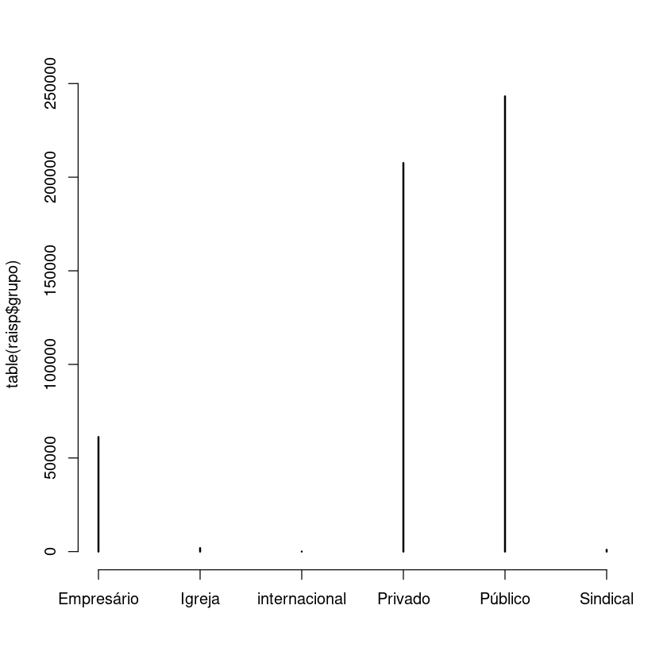

```r
table(raisp$grupo)
plot(table(raisp$grupo))
```

```r
dim(raisp)
```

1. 514796

2. 12

```r
length(unique(raisp$mun))
```

22

```r
head(raisp)
```

A data.frame: 6 × 12

|  | educ <fct> | sexo <fct> | idade <int> | tempo <dbl> | rem_dez <dbl> | raca <fct> | mun <int> | nat <dbl> | horas <int> | NN <int> | ano <dbl> | grupo <chr> |
| --- | --- | --- | --- | --- | --- | --- | --- | --- | --- | --- | --- | --- |
| 1 | Analfabeto | Masc | 38 | 6.32500000 | 0 | Parda | 120050 | 4081 | 44 | 1 | 2014 | Privado |
| 2 | Analfabeto | Masc | 60 | 2.71666667 | 0 | Preta | 120050 | 4081 | 44 | 2 | 2014 | Privado |
| 3 | Analfabeto | Masc | 61 | 5.49166667 | 0 | Branca | 120040 | 4081 | 44 | 3 | 2014 | Privado |
| 4 | Analfabeto | Masc | 54 | 4.90833333 | 0 | Parda | 120040 | 4081 | 44 | 4 | 2014 | Privado |
| 5 | Analfabeto | Masc | 62 | 4.98333333 | 0 | NA | 120040 | 2062 | 44 | 5 | 2014 | Privado |
| 6 | Analfabeto | Masc | 31 | 1.40833333 | 0 | Branca | 120040 | 2135 | 44 | 6 | 2014 | Empresário |

## Collapse, aggregate ou tapply dados

A data.frame: 6 × 3

|  | Renda <dbl> | desvio <dbl> | Quartis <list> |
| --- | --- | --- | --- |
| Empresário | 1117.72057 | 685.575403 | 0.000, 851.040, 1007.000, 1222.095, 95004.000 |
| Igreja | 1313.52666 | 723.823268 | 0.0, 880.0, 1158.4, 1630.0, 7811.8 |
| internacional | 2154.49937 | 1265.377430 | 670.3600, 953.6650, 1680.7950, 3490.7425, 3855.2400 |
| Privado | 1593.45738 | 1637.675390 | 0.00, 943.91, 1200.00, 1676.58, 74172.06 |
| Público | 3735.91578 | 4267.616376 | 0.0000, 1555.4300, 2567.5500, 4138.0425, 100674.0800 |
| Sindical | 1725.42342 | 1764.263840 | 0.000, 938.210, 1218.800, 1847.655, 19268.000 |

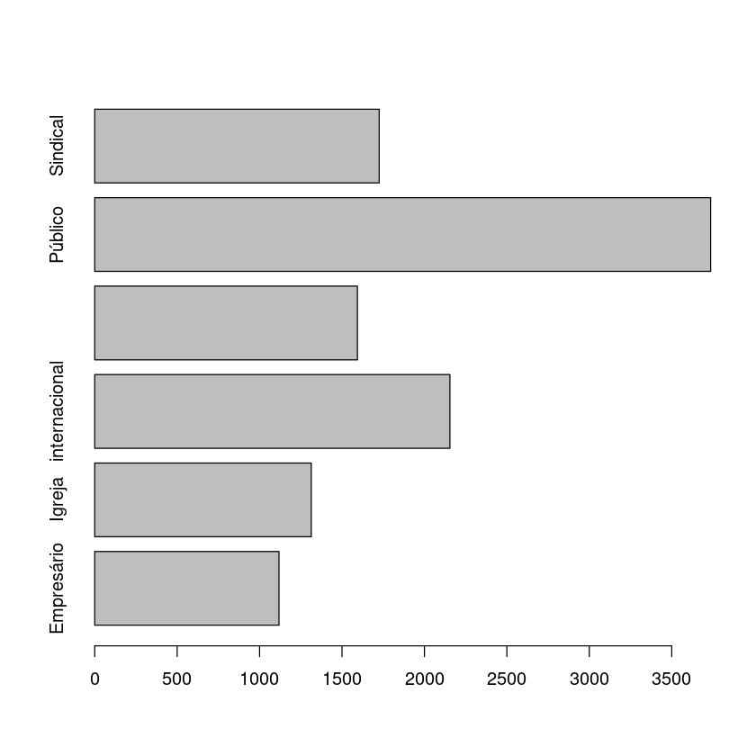

```r
d <-    data.frame(tapply(raisp$rem_dez,raisp$grupo,  mean, na.rm = TRUE)) # tapply não funciona se existir label factor sem valores
d[2] <- data.frame(tapply(raisp$rem_dez,raisp$grupo,  sd, na.rm = TRUE))
d[3] <- data.frame(tapply(raisp$rem_dez,raisp$grupo,  quantile, na.rm = TRUE))
     colnames(d) <-c("Renda",  "desvio",  "Quartis")
d
barplot(d[,1], horiz = T, names.arg = rownames(d)
       )
```

```r
table(raisp$grupo[raisp$rem_dez>100000])
```

```
Público
      1
```

```r
d <-    data.frame(tapply(raisp$tempo,raisp$grupo,  mean, na.rm = TRUE)) # tapply não funciona se existir label factor sem valores
d[2] <- data.frame(tapply(raisp$tempo,raisp$grupo,  sd, na.rm = TRUE))
d[3] <- data.frame(tapply(raisp$tempo,raisp$grupo,  quantile, na.rm = TRUE))
     colnames(d) <-c("Renda",  "desvio",  "Quartis")
d
```

A data.frame: 6 × 3

|  | Renda <dbl> | desvio <dbl> | Quartis <list> |
| --- | --- | --- | --- |
| Empresário | 2.44028356 | 2.91875975 | 0.00000000, 0.57500000, 1.49166667, 3.15833333, 44.40833333 |
| Igreja | 6.10440546 | 6.32447094 | 0.0333333333, 1.4333333333, 3.7416666667, 8.9916666667, 31.3250000000 |
| internacional | 3.40937500 | 2.37686355 | 0.22500000, 1.23750000, 3.47916667, 5.29791667, 7.15833333 |
| Privado | 2.86394174 | 3.51631210 | 0.00000000, 0.65000000, 1.67500000, 3.76666667, 45.32500000 |
| Público | 13.81270681 | 11.40314212 | 0.00000000, 2.86666667, 10.46666667, 24.40833333, 49.99166667 |
| Sindical | 6.50305929 | 6.14770656 | 0.00833333333, 1.82083333333, 4.65833333333, 9.20000000000, 31.90833333333 |

```r
d <-    data.frame(tapply(raisp$horas,raisp$grupo,  mean, na.rm = TRUE)) # tapply não funciona se existir label factor sem valores
d[2] <- data.frame(tapply(raisp$horas,raisp$grupo,  sd, na.rm = TRUE))
d[3] <- data.frame(tapply(raisp$horas,raisp$grupo,  quantile, na.rm = TRUE))
     colnames(d) <-c("Renda",  "desvio",  "Quartis")
d
```

A data.frame: 6 × 3

|  | Renda <dbl> | desvio <dbl> | Quartis <list> |
| --- | --- | --- | --- |
| Empresário | 43.5266899 | 2.83749132 | 1, 44, 44, 44, 44 |
| Igreja | 36.9673273 | 8.96967043 | 7, 36, 44, 44, 44 |
| internacional | 40.0000000 | 10.93008082 | 12, 44, 44, 44, 44 |
| Privado | 42.1584178 | 5.45195470 | 1, 44, 44, 44, 44 |
| Público | 35.7107880 | 6.82827245 | 1, 30, 40, 40, 44 |
| Sindical | 42.2771458 | 4.60912374 | 4, 44, 44, 44, 44 |

```r
table(raisp$grupo,raisp$sexo)
```

```
                  Masc   Femi
  Empresário     36620  24583
  Igreja           666   1201
  internacional      5     11
  Privado       128327  79238
  Público       109947 133231
  Sindical         445    522
```

```r
table(raisp$grupo,raisp$raca)
```

```
                Indigina Branca  Preta Amarela  Parda     NA
  Empresário          48   5814    659     439  37433  16810
  Igreja               2    342     39     119   1308     57
  internacional        0      0      0       0     11      5
  Privado            216  25953   3662    2144 132808  42782
  Público             78   5082    830     205  14078 222905
  Sindical             4    131     20       6    633    173
```

```r
# Salvar os dados como um csv
#readr::write_csv(raisCO, "Exemplos/raisCO.csv")
# Salvar os dados como um txt

#write_csv2(raisp, "Exemplos/rais2014_2017.txt")

#readr::write_delim(raisp, "rais2014_2017.txt", delim = ';', col_names=TRUE)

saveRDS(raisp, "rais2014_2017.RDS")

fst::write_fst(raisp, "rais2014_2017.fst")
```

```r
setwd("mnt/Disco1/Jupyter/R/myprogs/03 Gestao de dados/Exemplos/Rais/")
```

```r
#raisp<-readr::read_delim("Exemplos/rais2014_2017.txt", delim = ';', col_names=TRUE)
#read_delim("rais2014_2017.txt", delim = ';', col_names=TRUE)

raisp<-readRDS("rais2014_2017.RDS")
```

```r
head(raisp, 10)
```

A data.frame: 10 × 12

|  | educ <fct> | sexo <fct> | idade <int> | tempo <dbl> | rem_dez <dbl> | raca <fct> | mun <int> | nat <dbl> | horas <int> | NN <int> | ano <dbl> | grupo <chr> |
| --- | --- | --- | --- | --- | --- | --- | --- | --- | --- | --- | --- | --- |
| 1 | Analfabeto | Masc | 38 | 6.325000 | 0 | Parda | 120050 | 4081 | 44 | 1 | 2014 | Privado |
| 2 | Analfabeto | Masc | 60 | 2.716667 | 0 | Preta | 120050 | 4081 | 44 | 2 | 2014 | Privado |
| 3 | Analfabeto | Masc | 61 | 5.491667 | 0 | Branca | 120040 | 4081 | 44 | 3 | 2014 | Privado |
| 4 | Analfabeto | Masc | 54 | 4.908333 | 0 | Parda | 120040 | 4081 | 44 | 4 | 2014 | Privado |
| 5 | Analfabeto | Masc | 62 | 4.983333 | 0 | NA | 120040 | 2062 | 44 | 5 | 2014 | Privado |
| 6 | Analfabeto | Masc | 31 | 1.408333 | 0 | Branca | 120040 | 2135 | 44 | 6 | 2014 | Empresário |
| 7 | Analfabeto | Masc | 55 | 11.491667 | 0 | NA | 120040 | 2062 | 44 | 7 | 2014 | Privado |
| 8 | Analfabeto | Masc | 37 | 2.800000 | 0 | Parda | 120040 | 2062 | 44 | 8 | 2014 | Privado |
| 9 | Analfabeto | Masc | 39 | 8.158333 | 0 | Preta | 120040 | 2135 | 44 | 9 | 2014 | Empresário |
| 10 | Analfabeto | Masc | 44 | 2.325000 | 0 | Parda | 120040 | 2135 | 44 | 10 | 2014 | Empresário |

### Para painel de municípios

```r
names(raisp)
```

1. 'educ'

2. 'sexo'

3. 'idade'

4. 'tempo'

5. 'rem_dez'

6. 'raca'

7. 'mun'

8. 'nat'

9. 'horas'

10. 'NN'

11. 'ano'

12. 'grupo'

```r
raisp$um<-1
```

```r
summary(raisp)
```

```
              educ          sexo            idade            tempo
 Médio          :251773   Masc:276010   Min.   :  0.00   Min.   : 0.0000
 Superior       :140534   Femi:238786   1st Qu.: 29.00   1st Qu.: 0.9917
 Fundamental    : 37727                 Median : 36.00   Median : 3.2417
 Medio incomp   : 20086                 Mean   : 37.78   Mean   : 8.0041
 até 9a inc     : 17223                 3rd Qu.: 46.00   3rd Qu.:10.7500
 Superior incomp: 16723                 Max.   :100.00   Max.   :49.9917
 (Other)        : 30730
    rem_dez             raca             mun              nat
 Min.   :     0   Indigina:   348   Min.   :120001   Min.   :1015
 1st Qu.:  1012   Branca  : 37322   1st Qu.:120040   1st Qu.:1031
 Median :  1517   Preta   :  5210   Median :120040   Median :2054
 Mean   :  2548   Amarela :  2913   Mean   :120038   Mean   :1729
 3rd Qu.:  2814   Parda   :186271   3rd Qu.:120040   3rd Qu.:2062
 Max.   :100674   NA      :282732   Max.   :120080   Max.   :5037

     horas             NN              ano          grupo                 um
 Min.   : 1.00   Min.   :     1   Min.   :2014   Length:514796      Min.   :1
 1st Qu.:36.00   1st Qu.: 33484   1st Qu.:2014   Class :character   1st Qu.:1
 Median :44.00   Median : 67115   Median :2015   Mode  :character   Median :1
 Mean   :39.26   Mean   : 66701   Mean   :2015                      Mean   :1
 3rd Qu.:44.00   3rd Qu.: 99854   3rd Qu.:2016                      3rd Qu.:1
 Max.   :44.00   Max.   :136011   Max.   :2017                      Max.   :1
```

```r
raism1    <- aggregate(raisp[ ,c("idade","tempo" ,"rem_dez","horas" )],
                       by = list(raisp$mun,raisp$ano),FUN =  mean, na.rm = TRUE)
head(raism1)
```

A data.frame: 6 × 6

|  | Group.1 <int> | Group.2 <dbl> | idade <dbl> | tempo <dbl> | rem_dez <dbl> | horas <dbl> |
| --- | --- | --- | --- | --- | --- | --- |
| 1 | 120001 | 2014 | 34.89659 | 5.150156 | 1443.020 | 43.34983 |
| 2 | 120005 | 2014 | 37.85088 | 9.543567 | 1814.698 | 40.55263 |
| 3 | 120010 | 2014 | 34.56842 | 5.757485 | 1244.427 | 43.63860 |
| 4 | 120013 | 2014 | 36.00877 | 4.085292 | 1229.296 | 40.80351 |
| 5 | 120017 | 2014 | 37.33959 | 6.951382 | 1485.824 | 42.06260 |
| 6 | 120020 | 2014 | 33.95567 | 4.777994 | 1344.854 | 42.95543 |

```r
raisp$mulher<-0
raisp$mulher[raisp$sexo=="Femi"]<-1
```

```r
table(raisp$mulher)
```

```
     0      1
276010 238786
```

```r
table(raisp$educ)
```

```
     Analfabeto      Ate 5a inc      5a co fund      até 9a inc     Fundamental
           2171           16339            9388           17223           37727
   Medio incomp           Médio Superior incomp        Superior        Mestrado
          20086          251773           16723          140534            2299
      Doutorado
            533
```

```r
raisp$superior<-0
raisp$superior[raisp$educ=="Superior"]<-1
raisp$superior[raisp$educ=="Mestrado"]<-1
raisp$superior[raisp$educ=="Doutorado"]<-1
```

```r
table(raisp$superior)
```

```
     0      1
371430 143366
```

```r
raisp$menos_fund<-0
raisp$menos_fund[raisp$educ=="Analfabeto"]<-1
raisp$menos_fund[raisp$educ=="Ate 5a inc"]<-1
raisp$menos_fund[raisp$educ=="5a co fund"]<-1
raisp$menos_fund[raisp$educ=="até 9a inc"]<-1
```

```r
table(raisp$menos_fund)
```

```
     0      1
469675  45121
```

```r
table(raisp$grupo)
table(raisp$raca)
```

```
   Empresário        Igreja internacional       Privado       Público
        61203          1867            16        207565        243178
     Sindical
          967
```

```
Indigina   Branca    Preta  Amarela    Parda       NA
     348    37322     5210     2913   186271   282732
```

```r
raisp$empresario[raisp$grupo=="Empresário"]<-1
raisp$igreja[raisp$grupo=="Igreja"]<-1
raisp$sindical[raisp$grupo=="Sindical"]<-1
raisp$privado[raisp$grupo=="Privado"]<-1
raisp$publico[raisp$grupo=="Público"]<-1
raisp$branca[raisp$raca=="Branca"]<-1
raisp$parda[raisp$raca=="Parda"]<-1
raisp$preta[raisp$raca=="Preta"]<-1
```

```r
head(raisp)
```

A data.frame: 6 × 24

|  | educ <fct> | sexo <fct> | idade <int> | tempo <dbl> | rem_dez <dbl> | raca <fct> | mun <int> | nat <dbl> | horas <int> | NN <int> | ⋯ | superior <dbl> | menos_fund <dbl> | empresario <dbl> | igreja <dbl> | sindical <dbl> | privado <dbl> | publico <dbl> | branca <dbl> | parda <dbl> | preta <dbl> |
| --- | --- | --- | --- | --- | --- | --- | --- | --- | --- | --- | --- | --- | --- | --- | --- | --- | --- | --- | --- | --- | --- |
| 1 | Analfabeto | Masc | 38 | 6.325000 | 0 | Parda | 120050 | 4081 | 44 | 1 | ⋯ | 0 | 1 | NA | NA | NA | 1 | NA | NA | 1 | NA |
| 2 | Analfabeto | Masc | 60 | 2.716667 | 0 | Preta | 120050 | 4081 | 44 | 2 | ⋯ | 0 | 1 | NA | NA | NA | 1 | NA | NA | NA | 1 |
| 3 | Analfabeto | Masc | 61 | 5.491667 | 0 | Branca | 120040 | 4081 | 44 | 3 | ⋯ | 0 | 1 | NA | NA | NA | 1 | NA | 1 | NA | NA |
| 4 | Analfabeto | Masc | 54 | 4.908333 | 0 | Parda | 120040 | 4081 | 44 | 4 | ⋯ | 0 | 1 | NA | NA | NA | 1 | NA | NA | 1 | NA |
| 5 | Analfabeto | Masc | 62 | 4.983333 | 0 | NA | 120040 | 2062 | 44 | 5 | ⋯ | 0 | 1 | NA | NA | NA | 1 | NA | NA | NA | NA |
| 6 | Analfabeto | Masc | 31 | 1.408333 | 0 | Branca | 120040 | 2135 | 44 | 6 | ⋯ | 0 | 1 | 1 | NA | NA | NA | NA | 1 | NA | NA |

```r
raism2    <- aggregate(raisp[,c("um" ,"mulher", "menos_fund","superior",
                                "empresario","igreja", "sindical","privado", "publico",
                               "branca", "parda", "preta")],
                       by = list(raisp$mun,raisp$ano),FUN =  sum, na.rm = TRUE)
head(raism2)
```

A data.frame: 6 × 14

|  | Group.1 <int> | Group.2 <dbl> | um <dbl> | mulher <dbl> | menos_fund <dbl> | superior <dbl> | empresario <dbl> | igreja <dbl> | sindical <dbl> | privado <dbl> | publico <dbl> | branca <dbl> | parda <dbl> | preta <dbl> |
| --- | --- | --- | --- | --- | --- | --- | --- | --- | --- | --- | --- | --- | --- | --- |
| 1 | 120001 | 2014 | 909 | 381 | 151 | 188 | 133 | 2 | 0 | 382 | 392 | 266 | 475 | 27 |
| 2 | 120005 | 2014 | 342 | 200 | 40 | 54 | 50 | 1 | 0 | 52 | 239 | 41 | 232 | 15 |
| 3 | 120010 | 2014 | 1710 | 812 | 241 | 233 | 440 | 0 | 0 | 684 | 586 | 128 | 1255 | 31 |
| 4 | 120013 | 2014 | 1140 | 540 | 279 | 119 | 124 | 2 | 0 | 751 | 263 | 105 | 642 | 39 |
| 5 | 120017 | 2014 | 639 | 252 | 125 | 118 | 82 | 1 | 0 | 182 | 374 | 45 | 474 | 9 |
| 6 | 120020 | 2014 | 8144 | 3724 | 633 | 901 | 2152 | 79 | 5 | 3472 | 2436 | 1217 | 3788 | 62 |

```r
for (var in c("mulher", "menos_fund","superior",
"empresario","igreja", "sindical","privado", "publico",
"branca", "parda", "preta") ){

    raism2[[var]]<-  raism2[[var]]/raism2[["um"]]

}
head(raism2)
```

A data.frame: 6 × 14

|  | Group.1 <int> | Group.2 <dbl> | um <dbl> | mulher <dbl> | menos_fund <dbl> | superior <dbl> | empresario <dbl> | igreja <dbl> | sindical <dbl> | privado <dbl> | publico <dbl> | branca <dbl> | parda <dbl> | preta <dbl> |
| --- | --- | --- | --- | --- | --- | --- | --- | --- | --- | --- | --- | --- | --- | --- |
| 1 | 120001 | 2014 | 909 | 0.4191419 | 0.16611661 | 0.2068207 | 0.1463146 | 0.002200220 | 0.0000000000 | 0.4202420 | 0.4312431 | 0.29262926 | 0.5225523 | 0.029702970 |
| 2 | 120005 | 2014 | 342 | 0.5847953 | 0.11695906 | 0.1578947 | 0.1461988 | 0.002923977 | 0.0000000000 | 0.1520468 | 0.6988304 | 0.11988304 | 0.6783626 | 0.043859649 |
| 3 | 120010 | 2014 | 1710 | 0.4748538 | 0.14093567 | 0.1362573 | 0.2573099 | 0.000000000 | 0.0000000000 | 0.4000000 | 0.3426901 | 0.07485380 | 0.7339181 | 0.018128655 |
| 4 | 120013 | 2014 | 1140 | 0.4736842 | 0.24473684 | 0.1043860 | 0.1087719 | 0.001754386 | 0.0000000000 | 0.6587719 | 0.2307018 | 0.09210526 | 0.5631579 | 0.034210526 |
| 5 | 120017 | 2014 | 639 | 0.3943662 | 0.19561815 | 0.1846635 | 0.1283255 | 0.001564945 | 0.0000000000 | 0.2848200 | 0.5852895 | 0.07042254 | 0.7417840 | 0.014084507 |
| 6 | 120020 | 2014 | 8144 | 0.4572692 | 0.07772593 | 0.1106336 | 0.2642436 | 0.009700393 | 0.0006139489 | 0.4263261 | 0.2991159 | 0.14943517 | 0.4651277 | 0.007612967 |

```r
raism <- merge(raism1,raism2, by = c("Group.1","Group.2"))
```

```r
names(raism)
```

3. 'idade'

4. 'tempo'

5. 'rem_dez'

6. 'horas'

7. 'um'

8. 'mulher'

9. 'menos_fund'

10. 'superior'

11. 'empresario'

12. 'igreja'

13. 'sindical'

14. 'privado'

15. 'publico'

16. 'branca'

17. 'parda'

18. 'preta'

```r
names(raism)<-c("mun", "ano", names(raism)[-1:-2])
head(raism)
```

A data.frame: 6 × 18

|  | mun <int> | ano <dbl> | idade <dbl> | tempo <dbl> | rem_dez <dbl> | horas <dbl> | um <dbl> | mulher <dbl> | menos_fund <dbl> | superior <dbl> | empresario <dbl> | igreja <dbl> | sindical <dbl> | privado <dbl> | publico <dbl> | branca <dbl> | parda <dbl> | preta <dbl> |
| --- | --- | --- | --- | --- | --- | --- | --- | --- | --- | --- | --- | --- | --- | --- | --- | --- | --- | --- |
| 1 | 120001 | 2014 | 34.89659 | 5.150156 | 1443.020 | 43.34983 | 909 | 0.4191419 | 0.16611661 | 0.2068207 | 0.1463146 | 0.002200220 | 0 | 0.4202420 | 0.4312431 | 0.2926293 | 0.5225523 | 0.02970297 |
| 2 | 120001 | 2015 | 35.04301 | 5.524507 | 1544.460 | 43.37527 | 930 | 0.4032258 | 0.17741935 | 0.2000000 | 0.1709677 | 0.002150538 | 0 | 0.4172043 | 0.4096774 | 0.2849462 | 0.5408602 | 0.03655914 |
| 3 | 120001 | 2016 | 35.72845 | 6.405087 | 1706.075 | 43.42031 | 847 | 0.3907910 | 0.17591499 | 0.2066116 | 0.1770956 | 0.001180638 | 0 | 0.4203070 | 0.4014168 | 0.2868949 | 0.5844156 | 0.03659976 |
| 4 | 120001 | 2017 | 36.23991 | 6.702682 | 1810.658 | 43.14648 | 867 | 0.4059977 | 0.16608997 | 0.2168397 | 0.1637832 | 0.003460208 | 0 | 0.4129181 | 0.4198385 | 0.2906574 | 0.5709343 | 0.04036909 |
| 5 | 120005 | 2014 | 37.85088 | 9.543567 | 1814.698 | 40.55263 | 342 | 0.5847953 | 0.11695906 | 0.1578947 | 0.1461988 | 0.002923977 | 0 | 0.1520468 | 0.6988304 | 0.1198830 | 0.6783626 | 0.04385965 |
| 6 | 120005 | 2015 | 37.24044 | 8.925342 | 1990.124 | 41.34699 | 366 | 0.6256831 | 0.09836066 | 0.1693989 | 0.1147541 | 0.002732240 | 0 | 0.1475410 | 0.7349727 | 0.1092896 | 0.6256831 | 0.04644809 |

```r
dim(raism)
```

1. 88

2. 18

```r
####  LEITURA DE UM XLSX   ####
# ler dados de munícípios para fazer merge com a rais
# Planilhas contidas no arquivo
readxl::excel_sheets("PIB dos Municipios - base de dados 2010-2017.xls")
```

'PIB_dos_Municípios'

```r
# Fazer a leitura de uma planilha específica
pibmun <- readxl::read_excel("PIB dos Municipios - base de dados 2010-2017.xls",
                             sheet = 'PIB_dos_Municípios') # usando o nome
           # usando a posição

# Acesse http://readxl.tidyverse.org/index.html para entender outras funcionalidades
```

```r
names(pibmun)
```

1. 'Ano'

2. 'Código da Grande Região'

3. 'Nome da Grande Região'

4. 'Código da Unidade da Federação'

5. 'Sigla da Unidade da Federação'

6. 'Nome da Unidade da Federação'

7. 'Código do Município'

8. 'Nome do Município'

9. 'Região Metropolitana'

10. 'Código da Mesorregião'

11. 'Nome da Mesorregião'

12. 'Código da Microrregião'

13. 'Nome da Microrregião'

14. 'Código da Região Geográfica Imediata'

15. 'Nome da Região Geográfica Imediata'

16. 'Município da Região Geográfica Imediata'

17. 'Código da Região Geográfica Intermediária'

18. 'Nome da Região Geográfica Intermediária'

19. 'Município da Região Geográfica Intermediária'

20. 'Código Concentração Urbana'

21. 'Nome Concentração Urbana'

22. 'Tipo Concentração Urbana'

23. 'Código Arranjo Populacional'

24. 'Nome Arranjo Populacional'

25. 'Hierarquia Urbana'

26. 'Hierarquia Urbana (principais categorias)'

27. 'Código da Região Rural'

28. 'Nome da Região Rural'

29. 'Região rural (segundo classificação do núcleo)'

30. 'Amazônia Legal'

31. 'Semiárido'

32. 'Cidade-Região de São Paulo'

33. 'Valor adicionado bruto da Agropecuária, \na preços correntes\n(R$ 1.000)'

34. 'Valor adicionado bruto da Indústria,\na preços correntes\n(R$ 1.000)'

35. 'Valor adicionado bruto dos Serviços,\na preços correntes \n- exceto Administração, defesa, educação e saúde públicas e seguridade social\n(R$ 1.000)'

36. 'Valor adicionado bruto da Administração, defesa, educação e saúde públicas e seguridade social, \na preços correntes\n(R$ 1.000)'

37. 'Valor adicionado bruto total, \na preços correntes\n(R$ 1.000)'

38. 'Impostos, líquidos de subsídios, sobre produtos, \na preços correntes\n(R$ 1.000)'

39. 'Produto Interno Bruto, \na preços correntes\n(R$ 1.000)'

40. 'Produto Interno Bruto per capita, \na preços correntes\n(R$ 1,00)'

41. 'Atividade com maior valor adicionado bruto'

42. 'Atividade com segundo maior valor adicionado bruto'

43. 'Atividade com terceiro maior valor adicionado bruto'

```r
nomesO<-c('Ano', 'Código do Município', 'Nome do Município', 'Valor adicionado bruto da Agropecuária, \na preços correntes\n(R$ 1.000)', 'Valor adicionado bruto da Indústria,\na preços correntes\n(R$ 1.000)',
  'Valor adicionado bruto dos Serviços,\na preços correntes \n- exceto Administração, defesa, educação e saúde públicas e seguridade social\n(R$ 1.000)',
  'Valor adicionado bruto da Administração, defesa, educação e saúde públicas e seguridade social, \na preços correntes\n(R$ 1.000)',
  'Valor adicionado bruto total, \na preços correntes\n(R$ 1.000)',
  'Impostos, líquidos de subsídios, sobre produtos, \na preços correntes\n(R$ 1.000)',
  'Produto Interno Bruto, \na preços correntes\n(R$ 1.000)',
  'Produto Interno Bruto per capita, \na preços correntes\n(R$ 1,00)')
newnames<- c('ano', 'mun', 'munic', 'VAB_Agro', 'VAB_Ind', 'VAB_Serv', 'VAB_gov', 'VAB',  'Imposto',  'PIB',  'PIB_pk')
```

```r
pibmun<-pibmun[,nomesO]
names(pibmun)
```

1. 'Ano'

2. 'Código do Município'

3. 'Nome do Município'

4. 'Valor adicionado bruto da Agropecuária, \na preços correntes\n(R$ 1.000)'

5. 'Valor adicionado bruto da Indústria,\na preços correntes\n(R$ 1.000)'

6. 'Valor adicionado bruto dos Serviços,\na preços correntes \n- exceto Administração, defesa, educação e saúde públicas e seguridade social\n(R$ 1.000)'

7. 'Valor adicionado bruto da Administração, defesa, educação e saúde públicas e seguridade social, \na preços correntes\n(R$ 1.000)'

8. 'Valor adicionado bruto total, \na preços correntes\n(R$ 1.000)'

9. 'Impostos, líquidos de subsídios, sobre produtos, \na preços correntes\n(R$ 1.000)'

10. 'Produto Interno Bruto, \na preços correntes\n(R$ 1.000)'

11. 'Produto Interno Bruto per capita, \na preços correntes\n(R$ 1,00)'

```r
colnames(pibmun)<-newnames
names(pibmun)
```

1. 'ano'

2. 'mun'

3. 'munic'

4. 'VAB_Agro'

5. 'VAB_Ind'

6. 'VAB_Serv'

7. 'VAB_gov'

8. 'VAB'

9. 'Imposto'

10. 'PIB'

11. 'PIB_pk'

- deletar duplicados

```r
pibmun<-pibmun[!duplicated(pibmun),]
pibmun<-dplyr::distinct(pibmun)
```

```r
head(pibmun)
```

A tibble: 6 × 11

| ano <dbl> | mun <dbl> | munic <chr> | VAB_Agro <dbl> | VAB_Ind <dbl> | VAB_Serv <dbl> | VAB_gov <dbl> | VAB <dbl> | Imposto <dbl> | PIB <dbl> | PIB_pk <dbl> |
| --- | --- | --- | --- | --- | --- | --- | --- | --- | --- | --- |
| 2010 | 1100015 | Alta Floresta D'Oeste | 69260.39 | 16118.534 | 62496.18 | 93244.66 | 241119.77 | 20957.111 | 262076.88 | 10731.18 |
| 2010 | 1100023 | Ariquemes | 73711.64 | 287138.585 | 494946.27 | 343867.73 | 1199664.23 | 165029.553 | 1364693.78 | 15103.86 |
| 2010 | 1100031 | Cabixi | 24300.82 | 3252.506 | 12677.21 | 25170.24 | 65400.77 | 4210.342 | 69611.11 | 11033.62 |
| 2010 | 1100049 | Cacoal | 95259.20 | 182051.537 | 465447.33 | 298454.31 | 1041212.37 | 145281.717 | 1186494.09 | 15095.15 |
| 2010 | 1100056 | Cerejeiras | 28976.42 | 19734.484 | 80724.99 | 63018.27 | 192454.16 | 29567.029 | 222021.19 | 13037.06 |
| 2010 | 1100064 | Colorado do Oeste | 35817.58 | 18305.912 | 54678.24 | 67462.04 | 176263.77 | 16828.821 | 193092.60 | 10380.21 |

```r
head(raism)
```

A data.frame: 6 × 18

|  | mun <int> | ano <dbl> | idade <dbl> | tempo <dbl> | rem_dez <dbl> | horas <dbl> | um <dbl> | mulher <dbl> | menos_fund <dbl> | superior <dbl> | empresario <dbl> | igreja <dbl> | sindical <dbl> | privado <dbl> | publico <dbl> | branca <dbl> | parda <dbl> | preta <dbl> |
| --- | --- | --- | --- | --- | --- | --- | --- | --- | --- | --- | --- | --- | --- | --- | --- | --- | --- | --- |
| 1 | 120001 | 2014 | 34.89659 | 5.150156 | 1443.020 | 43.34983 | 909 | 0.4191419 | 0.16611661 | 0.2068207 | 0.1463146 | 0.002200220 | 0 | 0.4202420 | 0.4312431 | 0.2926293 | 0.5225523 | 0.02970297 |
| 2 | 120001 | 2015 | 35.04301 | 5.524507 | 1544.460 | 43.37527 | 930 | 0.4032258 | 0.17741935 | 0.2000000 | 0.1709677 | 0.002150538 | 0 | 0.4172043 | 0.4096774 | 0.2849462 | 0.5408602 | 0.03655914 |
| 3 | 120001 | 2016 | 35.72845 | 6.405087 | 1706.075 | 43.42031 | 847 | 0.3907910 | 0.17591499 | 0.2066116 | 0.1770956 | 0.001180638 | 0 | 0.4203070 | 0.4014168 | 0.2868949 | 0.5844156 | 0.03659976 |
| 4 | 120001 | 2017 | 36.23991 | 6.702682 | 1810.658 | 43.14648 | 867 | 0.4059977 | 0.16608997 | 0.2168397 | 0.1637832 | 0.003460208 | 0 | 0.4129181 | 0.4198385 | 0.2906574 | 0.5709343 | 0.04036909 |
| 5 | 120005 | 2014 | 37.85088 | 9.543567 | 1814.698 | 40.55263 | 342 | 0.5847953 | 0.11695906 | 0.1578947 | 0.1461988 | 0.002923977 | 0 | 0.1520468 | 0.6988304 | 0.1198830 | 0.6783626 | 0.04385965 |
| 6 | 120005 | 2015 | 37.24044 | 8.925342 | 1990.124 | 41.34699 | 366 | 0.6256831 | 0.09836066 | 0.1693989 | 0.1147541 | 0.002732240 | 0 | 0.1475410 | 0.7349727 | 0.1092896 | 0.6256831 | 0.04644809 |

```r
pibmun$mun<-pibmun$mun%/%10
```

```r
head(pibmun)
```

A tibble: 6 × 11

| ano <dbl> | mun <dbl> | munic <chr> | VAB_Agro <dbl> | VAB_Ind <dbl> | VAB_Serv <dbl> | VAB_gov <dbl> | VAB <dbl> | Imposto <dbl> | PIB <dbl> | PIB_pk <dbl> |
| --- | --- | --- | --- | --- | --- | --- | --- | --- | --- | --- |
| 2010 | 110001 | Alta Floresta D'Oeste | 69260.39 | 16118.534 | 62496.18 | 93244.66 | 241119.77 | 20957.111 | 262076.88 | 10731.18 |
| 2010 | 110002 | Ariquemes | 73711.64 | 287138.585 | 494946.27 | 343867.73 | 1199664.23 | 165029.553 | 1364693.78 | 15103.86 |
| 2010 | 110003 | Cabixi | 24300.82 | 3252.506 | 12677.21 | 25170.24 | 65400.77 | 4210.342 | 69611.11 | 11033.62 |
| 2010 | 110004 | Cacoal | 95259.20 | 182051.537 | 465447.33 | 298454.31 | 1041212.37 | 145281.717 | 1186494.09 | 15095.15 |
| 2010 | 110005 | Cerejeiras | 28976.42 | 19734.484 | 80724.99 | 63018.27 | 192454.16 | 29567.029 | 222021.19 | 13037.06 |
| 2010 | 110006 | Colorado do Oeste | 35817.58 | 18305.912 | 54678.24 | 67462.04 | 176263.77 | 16828.821 | 193092.60 | 10380.21 |

```r
raism<-dplyr::left_join(raism, pibmun, by = c("mun","ano"))
```

```r
head(raism,8)
```

A data.frame: 8 × 27

|  | mun <dbl> | ano <dbl> | idade <dbl> | tempo <dbl> | rem_dez <dbl> | horas <dbl> | um <dbl> | mulher <dbl> | menos_fund <dbl> | superior <dbl> | ⋯ | preta <dbl> | munic <chr> | VAB_Agro <dbl> | VAB_Ind <dbl> | VAB_Serv <dbl> | VAB_gov <dbl> | VAB <dbl> | Imposto <dbl> | PIB <dbl> | PIB_pk <dbl> |
| --- | --- | --- | --- | --- | --- | --- | --- | --- | --- | --- | --- | --- | --- | --- | --- | --- | --- | --- | --- | --- | --- |
| 1 | 120001 | 2014 | 34.89659 | 5.150156 | 1443.020 | 43.34983 | 909 | 0.4191419 | 0.16611661 | 0.20682068 | ⋯ | 0.02970297 | Acrelândia | 72633.45 | 16274.293 | 35807.41 | 77943.18 | 202658.34 | 5163.418 | 207821.76 | 15266.42 |
| 2 | 120001 | 2015 | 35.04301 | 5.524507 | 1544.460 | 43.37527 | 930 | 0.4032258 | 0.17741935 | 0.20000000 | ⋯ | 0.03655914 | Acrelândia | 83733.21 | 13346.226 | 30176.11 | 80135.74 | 207391.28 | 5569.905 | 212961.19 | 15355.19 |
| 3 | 120001 | 2016 | 35.72845 | 6.405087 | 1706.075 | 43.42031 | 847 | 0.3907910 | 0.17591499 | 0.20661157 | ⋯ | 0.03659976 | Acrelândia | 91143.88 | 8850.553 | 45618.44 | 85106.34 | 230719.21 | 8890.754 | 239609.97 | 16969.54 |
| 4 | 120001 | 2017 | 36.23991 | 6.702682 | 1810.658 | 43.14648 | 867 | 0.4059977 | 0.16608997 | 0.21683968 | ⋯ | 0.04036909 | Acrelândia | 71991.99 | 7671.506 | 47349.79 | 91935.23 | 218948.51 | 10678.923 | 229627.43 | 15984.09 |
| 5 | 120005 | 2014 | 37.85088 | 9.543567 | 1814.698 | 40.55263 | 342 | 0.5847953 | 0.11695906 | 0.15789474 | ⋯ | 0.04385965 | Assis Brasil | 19746.18 | 2625.834 | 11013.64 | 38755.19 | 72140.84 | 1191.508 | 73332.35 | 11094.15 |
| 6 | 120005 | 2015 | 37.24044 | 8.925342 | 1990.124 | 41.34699 | 366 | 0.6256831 | 0.09836066 | 0.16939891 | ⋯ | 0.04644809 | Assis Brasil | 19363.47 | 1951.864 | 13055.51 | 41240.25 | 75611.09 | 1623.288 | 77234.38 | 11462.51 |
| 7 | 120005 | 2016 | 31.66387 | 3.906373 | 1733.225 | 42.73109 | 119 | 0.5294118 | 0.04201681 | 0.08403361 | ⋯ | 0.00000000 | Assis Brasil | 24232.88 | 2022.400 | 14205.00 | 42930.67 | 83390.95 | 1930.552 | 85321.50 | 12432.10 |
| 8 | 120005 | 2017 | 35.62823 | 5.906262 | 1454.246 | 40.62028 | 503 | 0.5427435 | 0.07753479 | 0.15308151 | ⋯ | 0.03180915 | Assis Brasil | 22123.79 | 2879.049 | 14549.60 | 49385.96 | 88938.40 | 2802.198 | 91740.59 | 13132.06 |

## Painel de dados

### reshape

```r
# library(reshape) or library(reshape2)
# melt() or cast()

# library(tidyr)
# pivot_wider(), pivot_longer(),

# versão antiga(spread(),gather())
```

nosso banco está no formato long, agora queremos que ele fique no formato wide

```r
library(tidyr)
library(dplyr)
raislong<-raisp[,c("NN", "ano", "educ", "sexo", "idade")]
head(raislong)
```

A data.frame: 6 × 5

[output not shown]

```r
raiswide<-pivot_wider(data = raislong, names_from = ano, values_from = c(educ, sexo, idade ))
head(raiswide)
```

A tibble: 6 × 13

| NN <int> | educ_2014 <fct> | educ_2015 <fct> | educ_2016 <fct> | educ_2017 <fct> | sexo_2014 <fct> | sexo_2015 <fct> | sexo_2016 <fct> | sexo_2017 <fct> | idade_2014 <int> | idade_2015 <int> | idade_2016 <int> | idade_2017 <int> |
| --- | --- | --- | --- | --- | --- | --- | --- | --- | --- | --- | --- | --- |
| 1 | Analfabeto | Analfabeto | Analfabeto | Analfabeto | Masc | Masc | Masc | Masc | 34 | 48 | 52 | 60 |
| 2 | Analfabeto | Analfabeto | Analfabeto | Analfabeto | Masc | Masc | Masc | Masc | 36 | 65 | 25 | 38 |
| 3 | Analfabeto | Analfabeto | Analfabeto | Analfabeto | Masc | Masc | Masc | Masc | 28 | 64 | 38 | 40 |
| 4 | Analfabeto | Analfabeto | Analfabeto | Analfabeto | Masc | Masc | Masc | Masc | 44 | 50 | 30 | 67 |
| 5 | Analfabeto | Analfabeto | Analfabeto | Analfabeto | Masc | Masc | Masc | Masc | 56 | 49 | 58 | 61 |
| 6 | Analfabeto | Analfabeto | Analfabeto | Analfabeto | Masc | Masc | Masc | Masc | 40 | 61 | 28 | 62 |

```r
raislongeduc<-    raiswide[,1:5] %>%
             pivot_longer( cols = educ_2014:educ_2017, names_to = c("ano"),
                        names_prefix = "educ_", values_to = c("educ") )
raislongsexo<-    raiswide[,c(1,6:9)] %>%
             pivot_longer( cols = sexo_2014:sexo_2017, names_to = c("ano"),
                        names_prefix = "sexo_", values_to = c("sexo") )
raislongidade<-    raiswide[,c(1,10:13)] %>%
             pivot_longer( cols = idade_2014:idade_2017, names_to = c("ano"),
                        names_prefix = "idade_", values_to = c("idade") )
raislong2 <- full_join(
                 full_join(raislongeduc, raislongidade, raislongsexo, by = c("NN", "ano")),
                       raislongsexo, by = c("NN", "ano"))
head(raislong2)

rm(raislongeduc, raislongsexo, raislongidade)

#https://dcl-wrangle.stanford.edu/pivot_advanced.html
```

A tibble: 6 × 5

| NN <int> | ano <chr> | educ <fct> | idade <int> | sexo <fct> |
| --- | --- | --- | --- | --- |
| 1 | 2014 | Analfabeto | 34 | Masc |
| 1 | 2015 | Analfabeto | 48 | Masc |
| 1 | 2016 | Analfabeto | 52 | Masc |
| 1 | 2017 | Analfabeto | 60 | Masc |
| 2 | 2014 | Analfabeto | 36 | Masc |
| 2 | 2015 | Analfabeto | 65 | Masc |

### Exercícios

1. Colocar comando pivot_longer para as três variáveis ao mesmo tempo gerando o mesmo resultado combinado anterior.

# Tabelas e estatísticas básicas

```r
summary(raisp$idade)
```

```
   Min. 1st Qu.  Median    Mean 3rd Qu.    Max.
   0.00   29.00   36.00   37.78   46.00  100.00
```

```r
table(raisp$educ, raisp$raca)
```

```
                  Indigina Branca  Preta Amarela  Parda     NA
  Analfabeto             0    154     74      13   1490    440
  Ate 5a inc            12   1105    451      96   7268   7407
  5a co fund            15   1149    379      76   5253   2516
  até 9a inc            26   1364    288     118   6688   8739
  Fundamental           60   2996    505     262  14659  19245
  Medio incomp          19   2794    391     248  11354   5280
  Médio                155  18725   2355    1653 113167 115718
  Superior incomp       12   1840    196     103   6508   8064
  Superior              49   6986    558     336  19371 113234
  Mestrado               0    113     13       8    406   1759
  Doutorado              0     96      0       0    107    330
```

```r
options(digits = 4)
prop.table(table(raisp$educ, raisp$raca),2)
```

```
                   Indigina    Branca     Preta   Amarela     Parda        NA
  Analfabeto      0.0000000 0.0041263 0.0142035 0.0044628 0.0079991 0.0015562
  Ate 5a inc      0.0344828 0.0296072 0.0865643 0.0329557 0.0390184 0.0261980
  5a co fund      0.0431034 0.0307861 0.0727447 0.0260899 0.0282008 0.0088989
  até 9a inc      0.0747126 0.0365468 0.0552783 0.0405081 0.0359047 0.0309091
  Fundamental     0.1724138 0.0802744 0.0969290 0.0899416 0.0786972 0.0680680
  Medio incomp    0.0545977 0.0748620 0.0750480 0.0851356 0.0609542 0.0186749
  Médio           0.4454023 0.5017148 0.4520154 0.5674562 0.6075396 0.4092851
  Superior incomp 0.0344828 0.0493007 0.0376200 0.0353587 0.0349383 0.0285217
  Superior        0.1408046 0.1871818 0.1071017 0.1153450 0.1039936 0.4004994
  Mestrado        0.0000000 0.0030277 0.0024952 0.0027463 0.0021796 0.0062214
  Doutorado       0.0000000 0.0025722 0.0000000 0.0000000 0.0005744 0.0011672
```

```r
quantile(raisp$rem_dez)
```

**0%**

0

**25%**

1011.96

**50%**

1517

**75%**

2813.97

**100%**

100674.08

```r
table(raisp$educ, raisp$sexo)
```

```
                    Masc   Femi
  Analfabeto        1923    248
  Ate 5a inc       11620   4719
  5a co fund        6752   2636
  até 9a inc       10800   6423
  Fundamental      22453  15274
  Medio incomp     12799   7287
  Médio           143798 107975
  Superior incomp   7877   8846
  Superior         56614  83920
  Mestrado          1020   1279
  Doutorado          354    179
```

```r
prop.table(table(raisp$educ, raisp$sexo),2)
```

```
                       Masc      Femi
  Analfabeto      0.0069671 0.0010386
  Ate 5a inc      0.0420999 0.0197625
  5a co fund      0.0244629 0.0110392
  até 9a inc      0.0391290 0.0268986
  Fundamental     0.0813485 0.0639652
  Medio incomp    0.0463715 0.0305169
  Médio           0.5209884 0.4521831
  Superior incomp 0.0285388 0.0370457
  Superior        0.2051158 0.3514444
  Mestrado        0.0036955 0.0053563
  Doutorado       0.0012826 0.0007496
```

```r
cor(raism$rem_dez, raism$PIB)
```

0.765144884305315

```r
d <-    data.frame(tapply(raisp$rem_dez,raisp$raca,  mean, na.rm = TRUE)) # tapply não funciona se existir label factor sem valores
d[2] <- data.frame(tapply(raisp$rem_dez,raisp$raca,  sd, na.rm = TRUE))
d[3] <- data.frame(tapply(raisp$rem_dez,raisp$raca,  quantile, na.rm = TRUE))
     colnames(d) <-c("Renda",  "desvio",  "Quartis")
d
```

A data.frame: 6 × 3

|  | Renda <dbl> | desvio <dbl> | Quartis <list> |
| --- | --- | --- | --- |
| Indigina | 1521 | 1647 | 0, 880, 1152, 1618, 18496 |
| Branca | 2344 | 3560 | 0.0, 969.8, 1338.2, 2276.2, 96217.6 |
| Preta | 1845 | 2252 | 0.0, 943.2, 1221.5, 1806.8, 37712.2 |
| Amarela | 1779 | 1888 | 0, 937, 1252, 1957, 28461 |
| Parda | 1631 | 2003 | 0, 937, 1160, 1646, 100674 |
| NA | 3202 | 3826 | 0, 1200, 2081, 3582, 93605 |

# Regressão

```r
names(raism)
```

1. 'mun'

2. 'ano'

3. 'idade'

4. 'tempo'

5. 'rem_dez'

6. 'horas'

7. 'um'

8. 'mulher'

9. 'menos_fund'

10. 'superior'

11. 'empresario'

12. 'igreja'

13. 'sindical'

14. 'privado'

15. 'publico'

16. 'branca'

17. 'parda'

18. 'preta'

19. 'munic'

20. 'VAB_Agro'

21. 'VAB_Ind'

22. 'VAB_Serv'

23. 'VAB_gov'

24. 'VAB'

25. 'Imposto'

26. 'PIB'

27. 'PIB_pk'

```r
summary(raism)
```

```
      mun              ano           idade          tempo          rem_dez
 Min.   :120001   Min.   :2014   Min.   :31.7   Min.   : 3.91   Min.   :1102
 1st Qu.:120020   1st Qu.:2015   1st Qu.:35.8   1st Qu.: 5.75   1st Qu.:1386
 Median :120034   Median :2016   Median :37.3   Median : 7.53   Median :1493
 Mean   :120035   Mean   :2016   Mean   :37.0   Mean   : 7.56   Mean   :1581
 3rd Qu.:120043   3rd Qu.:2016   3rd Qu.:38.2   3rd Qu.: 9.24   3rd Qu.:1666
 Max.   :120080   Max.   :2017   Max.   :41.6   Max.   :11.86   Max.   :3238
     horas            um             mulher        menos_fund
 Min.   :35.3   Min.   :   119   Min.   :0.256   Min.   :0.000
 1st Qu.:40.0   1st Qu.:   654   1st Qu.:0.403   1st Qu.:0.084
 Median :42.1   Median :   952   Median :0.443   Median :0.124
 Mean   :41.7   Mean   :  5850   Mean   :0.451   Mean   :0.127
 3rd Qu.:43.7   3rd Qu.:  1758   3rd Qu.:0.497   3rd Qu.:0.168
 Max.   :44.0   Max.   :104539   Max.   :0.626   Max.   :0.251
    superior        empresario         igreja           sindical
 Min.   :0.0049   Min.   :0.0094   Min.   :0.00000   Min.   :0.00e+00
 1st Qu.:0.1319   1st Qu.:0.0776   1st Qu.:0.00000   1st Qu.:0.00e+00
 Median :0.1630   Median :0.1489   Median :0.00109   Median :0.00e+00
 Mean   :0.1739   Mean   :0.1482   Mean   :0.00201   Mean   :3.13e-04
 3rd Qu.:0.2035   3rd Qu.:0.2095   3rd Qu.:0.00216   3rd Qu.:3.08e-05
 Max.   :0.3912   Max.   :0.4156   Max.   :0.02283   Max.   :3.10e-03
    privado          publico          branca           parda
 Min.   :0.0032   Min.   :0.126   Min.   :0.0015   Min.   :0.0181
 1st Qu.:0.0565   1st Qu.:0.409   1st Qu.:0.0276   1st Qu.:0.2483
 Median :0.3238   Median :0.495   Median :0.0559   Median :0.4058
 Mean   :0.2693   Mean   :0.580   Mean   :0.0743   Mean   :0.3956
 3rd Qu.:0.4118   3rd Qu.:0.772   3rd Qu.:0.0850   3rd Qu.:0.5651
 Max.   :0.7014   Max.   :0.974   Max.   :0.4638   Max.   :0.8908
     preta            munic              VAB_Agro         VAB_Ind
 Min.   :0.00000   Length:88          Min.   :  9797   Min.   :   1231
 1st Qu.:0.00526   Class :character   1st Qu.: 38985   1st Qu.:   4106
 Median :0.01083   Mode  :character   Median : 67192   Median :   9132
 Mean   :0.01930                      Mean   : 62174   Mean   :  53957
 3rd Qu.:0.02952                      3rd Qu.: 77011   3rd Qu.:  18772
 Max.   :0.09840                      Max.   :184944   Max.   :1011653
    VAB_Serv          VAB_gov             VAB             Imposto
 Min.   :   5023   Min.   :  34068   Min.   :  52542   Min.   :    852
 1st Qu.:  16037   1st Qu.:  62351   1st Qu.: 146565   1st Qu.:   2427
 Median :  29987   Median : 100396   Median : 204711   Median :   5581
 Mean   : 237972   Mean   : 215510   Mean   : 569613   Mean   :  56601
 3rd Qu.:  80460   3rd Qu.: 142377   3rd Qu.: 337611   3rd Qu.:  13718
 Max.   :4143928   Max.   :2364459   Max.   :7303578   Max.   :1072152
      PIB              PIB_pk
 Min.   :  53395   Min.   : 9083
 1st Qu.: 148767   1st Qu.:10510
 Median : 209783   Median :12534
 Mean   : 626214   Mean   :13282
 3rd Qu.: 353092   3rd Qu.:15355
 Max.   :8258089   Max.   :25139
```

```r
result <- lm(data =raism,rem_dez  ~ PIB +  idade + mulher + branca + parda + preta + horas +
             VAB_gov +  VAB_Ind + superior +  menos_fund + empresario + publico + igreja)
# estraindo estaísticas dos resultados
```

```r
summary(result)
 DegreesOfFreedom <- result$df
 Yhat <- result$fitted.values
 Coef <- result$coefficients
 Resid <- result$residuals
 RSquared <- result$r.squared
 aic <- AIC(result)
 bic <- BIC(result)
```

```
Call:
lm(formula = rem_dez ~ PIB + idade + mulher + branca + parda +
    preta + horas + VAB_gov + VAB_Ind + superior + menos_fund +
    empresario + publico + igreja, data = raism)

Residuals:
   Min     1Q Median     3Q    Max
-304.3 -113.2  -25.8   70.3  657.2

Coefficients:
             Estimate Std. Error t value Pr(>|t|)
(Intercept)  6.00e+02   8.09e+02    0.74  0.46060
PIB          8.13e-04   3.67e-04    2.22  0.02988 *
idade        3.56e+01   1.81e+01    1.97  0.05321 .
mulher      -1.64e+03   3.67e+02   -4.46  2.9e-05 ***
branca       2.09e+02   3.32e+02    0.63  0.53184
parda        5.02e+02   1.34e+02    3.73  0.00037 ***
preta       -3.12e+03   1.36e+03   -2.29  0.02495 *
horas        5.41e+00   1.19e+01    0.45  0.65200
VAB_gov     -1.05e-03   8.27e-04   -1.28  0.20607
VAB_Ind     -3.65e-03   1.53e-03   -2.39  0.01963 *
superior     7.28e+02   3.14e+02    2.32  0.02333 *
menos_fund  -1.50e+03   5.22e+02   -2.86  0.00547 **
empresario  -3.72e+02   3.96e+02   -0.94  0.35054
publico      9.19e+01   1.96e+02    0.47  0.64064
igreja       9.15e+02   6.66e+03    0.14  0.89100
---
Signif. codes:  0 ‘***’ 0.001 ‘**’ 0.01 ‘*’ 0.05 ‘.’ 0.1 ‘ ’ 1

Residual standard error: 190 on 73 degrees of freedom
Multiple R-squared:  0.774,	Adjusted R-squared:  0.731
F-statistic: 17.9 on 14 and 73 DF,  p-value: <2e-16
```

```r
raism$trend<- raism$ano-2013
```

```r
result <- glm(data =raism, rem_dez  ~ trend + PIB +  idade + mulher + branca + parda + preta + horas +
             VAB_gov +  VAB_Ind + superior +  menos_fund + empresario + sindical + igreja, family = quasipoisson(link = log))
# estraindo estaísticas dos resultados
```

```r
summary(result)
```

```
Call:
glm(formula = rem_dez ~ trend + PIB + idade + mulher + branca +
    parda + preta + horas + VAB_gov + VAB_Ind + superior + menos_fund +
    empresario + sindical + igreja, family = quasipoisson(link = log),
    data = raism)

Deviance Residuals:
   Min      1Q  Median      3Q     Max
-8.291  -2.864  -0.679   1.659  16.560

Coefficients:
             Estimate Std. Error t value Pr(>|t|)
(Intercept)  6.95e+00   5.18e-01   13.43  < 2e-16 ***
trend        3.83e-02   1.30e-02    2.96  0.00422 **
PIB          2.02e-07   2.17e-07    0.93  0.35347
idade        1.63e-02   1.14e-02    1.43  0.15742
mulher      -9.36e-01   2.10e-01   -4.46  2.9e-05 ***
branca       9.87e-02   1.96e-01    0.50  0.61649
parda        2.84e-01   7.58e-02    3.74  0.00036 ***
preta       -1.35e+00   9.19e-01   -1.47  0.14528
horas        1.22e-03   7.43e-03    0.16  0.87004
VAB_gov     -2.53e-07   4.86e-07   -0.52  0.60336
VAB_Ind     -6.57e-07   8.89e-07   -0.74  0.46239
superior     4.67e-01   1.97e-01    2.37  0.02067 *
menos_fund  -8.43e-01   2.99e-01   -2.82  0.00616 **
empresario  -2.36e-01   2.19e-01   -1.08  0.28511
sindical    -3.53e+00   2.49e+01   -0.14  0.88748
igreja       6.24e-01   3.78e+00    0.16  0.86943
---
Signif. codes:  0 ‘***’ 0.001 ‘**’ 0.01 ‘*’ 0.05 ‘.’ 0.1 ‘ ’ 1

(Dispersion parameter for quasipoisson family taken to be 20.41)

    Null deviance: 6469.0  on 87  degrees of freedom
Residual deviance: 1397.6  on 72  degrees of freedom
AIC: NA

Number of Fisher Scoring iterations: 4
```

```r
library(plm)
```

```r
names(raism)
```

1. 'mun'

2. 'ano'

3. 'idade'

4. 'tempo'

5. 'rem_dez'

6. 'horas'

7. 'um'

8. 'mulher'

9. 'menos_fund'

10. 'superior'

11. 'empresario'

12. 'igreja'

13. 'sindical'

14. 'privado'

15. 'publico'

16. 'branca'

17. 'parda'

18. 'preta'

19. 'munic'

20. 'VAB_Agro'

21. 'VAB_Ind'

22. 'VAB_Serv'

23. 'VAB_gov'

24. 'VAB'

25. 'Imposto'

26. 'PIB'

27. 'PIB_pk'

28. 'trend'

```r
raispainel=pdata.frame(raism, index=c("mun","ano"))
```

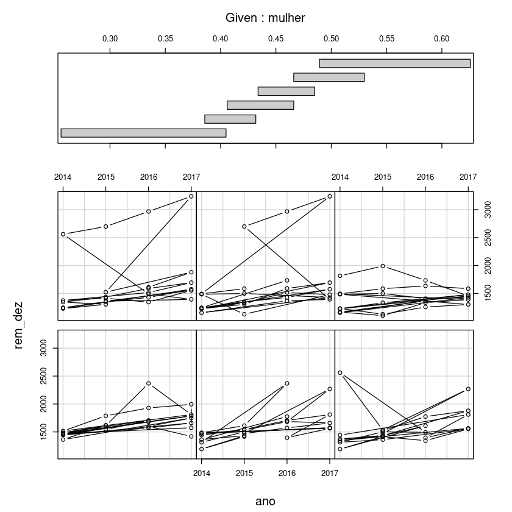

```r
coplot(rem_dez ~ ano|mulher, type="b", data=raispainel)
```

```r
regFE=plm(rem_dez  ~ PIB +  idade + mulher +  horas +
             VAB_gov +  VAB_Ind + superior +  menos_fund  + privado  ,
           data=raispainel, model="within")
summary(regFE)
```

```
Oneway (individual) effect Within Model

Call:
plm(formula = rem_dez ~ PIB + idade + mulher + horas + VAB_gov +
    VAB_Ind + superior + menos_fund + privado, data = raispainel,
    model = "within")

Balanced Panel: n = 22, T = 4, N = 88

Residuals:
   Min. 1st Qu.  Median 3rd Qu.    Max.
 -269.7   -55.9    -7.1    46.1   499.8

Coefficients:
            Estimate Std. Error t-value Pr(>|t|)
PIB         3.48e-04   5.25e-04    0.66  0.51078
idade       8.09e+01   2.27e+01    3.56  0.00076 ***
mulher     -9.08e+02   8.79e+02   -1.03  0.30627
horas       2.02e+01   4.32e+01    0.47  0.64216
VAB_gov     3.22e-03   1.98e-03    1.62  0.10993
VAB_Ind     1.99e-03   2.76e-03    0.72  0.47486
superior    3.16e+02   6.77e+02    0.47  0.64242
menos_fund -1.59e+03   1.14e+03   -1.40  0.16836
privado     6.36e+02   3.60e+02    1.77  0.08239 .
---
Signif. codes:  0 ‘***’ 0.001 ‘**’ 0.01 ‘*’ 0.05 ‘.’ 0.1 ‘ ’ 1

Total Sum of Squares:    2300000
Residual Sum of Squares: 1200000
R-Squared:      0.477
Adj. R-Squared: 0.201
F-statistic: 5.76915 on 9 and 57 DF, p-value: 1.14e-05
```

```r
gc()
```

A matrix: 2 × 6 of type dbl

|  | used | (Mb) | gc trigger | (Mb) | max used | (Mb) |
| --- | --- | --- | --- | --- | --- | --- |
| Ncells | 1131748 | 60.5 | 2433367 | 130.0 | 2433367 | 130.0 |
| Vcells | 13499951 | 103.0 | 47375523 | 361.5 | 46212497 | 352.6 |